# Risk Factor Analysis

## Outcome Variable

**Outcome Variable:** ever_stunted

## Predictor Variables

**Intervention Variable:** hhwealth_quart

**Adjustment Set:**

unadjusted

## Stratifying Variables

The analysis was stratified on these variable(s):

- agecat
- studyid
- country

## Data Summary

| agecat | studyid | country | hhwealth_quart | ever_stunted | n_cell | n |
| --- | --- | --- | --- | --- | --- | --- |
| 0-6 months | ki0047075b-MAL-ED | BANGLADESH | Wealth Q4 | 0 | 23 | 82 |
| 0-6 months | ki0047075b-MAL-ED | BANGLADESH | Wealth Q4 | 1 | 3 | 82 |
| 0-6 months | ki0047075b-MAL-ED | BANGLADESH | Wealth Q1 | 0 | 3 | 82 |
| 0-6 months | ki0047075b-MAL-ED | BANGLADESH | Wealth Q1 | 1 | 1 | 82 |
| 0-6 months | ki0047075b-MAL-ED | BANGLADESH | Wealth Q2 | 0 | 13 | 82 |
| 0-6 months | ki0047075b-MAL-ED | BANGLADESH | Wealth Q2 | 1 | 2 | 82 |
| 0-6 months | ki0047075b-MAL-ED | BANGLADESH | Wealth Q3 | 0 | 27 | 82 |
| 0-6 months | ki0047075b-MAL-ED | BANGLADESH | Wealth Q3 | 1 | 10 | 82 |
| 0-6 months | ki0047075b-MAL-ED | BRAZIL | Wealth Q4 | 0 | 1 | 3 |
| 0-6 months | ki0047075b-MAL-ED | BRAZIL | Wealth Q4 | 1 | 1 | 3 |
| 0-6 months | ki0047075b-MAL-ED | BRAZIL | Wealth Q2 | 0 | 0 | 3 |
| 0-6 months | ki0047075b-MAL-ED | BRAZIL | Wealth Q2 | 1 | 1 | 3 |
| 0-6 months | ki0047075b-MAL-ED | INDIA | Wealth Q4 | 0 | 23 | 71 |
| 0-6 months | ki0047075b-MAL-ED | INDIA | Wealth Q4 | 1 | 6 | 71 |
| 0-6 months | ki0047075b-MAL-ED | INDIA | Wealth Q1 | 0 | 1 | 71 |
| 0-6 months | ki0047075b-MAL-ED | INDIA | Wealth Q1 | 1 | 0 | 71 |
| 0-6 months | ki0047075b-MAL-ED | INDIA | Wealth Q2 | 0 | 8 | 71 |
| 0-6 months | ki0047075b-MAL-ED | INDIA | Wealth Q2 | 1 | 2 | 71 |
| 0-6 months | ki0047075b-MAL-ED | INDIA | Wealth Q3 | 0 | 24 | 71 |
| 0-6 months | ki0047075b-MAL-ED | INDIA | Wealth Q3 | 1 | 7 | 71 |
| 0-6 months | ki0047075b-MAL-ED | NEPAL | Wealth Q4 | 0 | 17 | 42 |
| 0-6 months | ki0047075b-MAL-ED | NEPAL | Wealth Q4 | 1 | 4 | 42 |
| 0-6 months | ki0047075b-MAL-ED | NEPAL | Wealth Q1 | 0 | 9 | 42 |
| 0-6 months | ki0047075b-MAL-ED | NEPAL | Wealth Q1 | 1 | 2 | 42 |
| 0-6 months | ki0047075b-MAL-ED | NEPAL | Wealth Q2 | 0 | 5 | 42 |
| 0-6 months | ki0047075b-MAL-ED | NEPAL | Wealth Q2 | 1 | 1 | 42 |
| 0-6 months | ki0047075b-MAL-ED | NEPAL | Wealth Q3 | 0 | 3 | 42 |
| 0-6 months | ki0047075b-MAL-ED | NEPAL | Wealth Q3 | 1 | 1 | 42 |
| 0-6 months | ki0047075b-MAL-ED | PERU | Wealth Q4 | 0 | 1 | 37 |
| 0-6 months | ki0047075b-MAL-ED | PERU | Wealth Q4 | 1 | 0 | 37 |

[output cut: 376 more lines]

The following strata were considered:

- agecat: 0-24 months, studyid: ki0047075b-MAL-ED, country: BANGLADESH
- agecat: 0-24 months, studyid: ki0047075b-MAL-ED, country: BRAZIL
- agecat: 0-24 months, studyid: ki0047075b-MAL-ED, country: INDIA
- agecat: 0-24 months, studyid: ki0047075b-MAL-ED, country: NEPAL
- agecat: 0-24 months, studyid: ki0047075b-MAL-ED, country: PERU
- agecat: 0-24 months, studyid: ki0047075b-MAL-ED, country: SOUTH AFRICA
- agecat: 0-24 months, studyid: ki0047075b-MAL-ED, country: TANZANIA, UNITED REPUBLIC OF
- agecat: 0-24 months, studyid: ki1000108-CMC-V-BCS-2002, country: INDIA
- agecat: 0-24 months, studyid: ki1000108-IRC, country: INDIA
- agecat: 0-24 months, studyid: ki1017093b-PROVIDE, country: BANGLADESH
- agecat: 0-24 months, studyid: ki1066203-TanzaniaChild2, country: TANZANIA, UNITED REPUBLIC OF
- agecat: 0-24 months, studyid: ki1113344-GMS-Nepal, country: NEPAL
- agecat: 0-24 months, studyid: ki1114097-CONTENT, country: PERU
- agecat: 0-24 months, studyid: ki1135781-COHORTS, country: GUATEMALA
- agecat: 0-24 months, studyid: ki1135781-COHORTS, country: PHILIPPINES
- agecat: 0-24 months, studyid: ki1148112-LCNI-5, country: MALAWI
- agecat: 0-24 months, studyid: kiGH5241-JiVitA-3, country: BANGLADESH
- agecat: 0-24 months, studyid: kiGH5241-JiVitA-4, country: BANGLADESH
- agecat: 0-6 months, studyid: ki0047075b-MAL-ED, country: BANGLADESH
- agecat: 0-6 months, studyid: ki0047075b-MAL-ED, country: BRAZIL
- agecat: 0-6 months, studyid: ki0047075b-MAL-ED, country: INDIA
- agecat: 0-6 months, studyid: ki0047075b-MAL-ED, country: NEPAL
- agecat: 0-6 months, studyid: ki0047075b-MAL-ED, country: PERU
- agecat: 0-6 months, studyid: ki0047075b-MAL-ED, country: SOUTH AFRICA
- agecat: 0-6 months, studyid: ki0047075b-MAL-ED, country: TANZANIA, UNITED REPUBLIC OF
- agecat: 0-6 months, studyid: ki1000108-CMC-V-BCS-2002, country: INDIA
- agecat: 0-6 months, studyid: ki1000108-IRC, country: INDIA
- agecat: 0-6 months, studyid: ki1017093b-PROVIDE, country: BANGLADESH
- agecat: 0-6 months, studyid: ki1066203-TanzaniaChild2, country: TANZANIA, UNITED REPUBLIC OF
- agecat: 0-6 months, studyid: ki1113344-GMS-Nepal, country: NEPAL
- agecat: 0-6 months, studyid: ki1114097-CONTENT, country: PERU
- agecat: 0-6 months, studyid: ki1135781-COHORTS, country: GUATEMALA
- agecat: 0-6 months, studyid: ki1135781-COHORTS, country: PHILIPPINES
- agecat: 0-6 months, studyid: ki1148112-LCNI-5, country: MALAWI
- agecat: 0-6 months, studyid: kiGH5241-JiVitA-3, country: BANGLADESH
- agecat: 0-6 months, studyid: kiGH5241-JiVitA-4, country: BANGLADESH
- agecat: 6-24 months, studyid: ki0047075b-MAL-ED, country: BANGLADESH
- agecat: 6-24 months, studyid: ki0047075b-MAL-ED, country: BRAZIL
- agecat: 6-24 months, studyid: ki0047075b-MAL-ED, country: INDIA
- agecat: 6-24 months, studyid: ki0047075b-MAL-ED, country: NEPAL
- agecat: 6-24 months, studyid: ki0047075b-MAL-ED, country: PERU
- agecat: 6-24 months, studyid: ki0047075b-MAL-ED, country: SOUTH AFRICA
- agecat: 6-24 months, studyid: ki0047075b-MAL-ED, country: TANZANIA, UNITED REPUBLIC OF
- agecat: 6-24 months, studyid: ki1000108-CMC-V-BCS-2002, country: INDIA
- agecat: 6-24 months, studyid: ki1000108-IRC, country: INDIA
- agecat: 6-24 months, studyid: ki1017093b-PROVIDE, country: BANGLADESH
- agecat: 6-24 months, studyid: ki1066203-TanzaniaChild2, country: TANZANIA, UNITED REPUBLIC OF
- agecat: 6-24 months, studyid: ki1113344-GMS-Nepal, country: NEPAL
- agecat: 6-24 months, studyid: ki1114097-CONTENT, country: PERU
- agecat: 6-24 months, studyid: ki1135781-COHORTS, country: GUATEMALA
- agecat: 6-24 months, studyid: ki1135781-COHORTS, country: PHILIPPINES
- agecat: 6-24 months, studyid: ki1148112-LCNI-5, country: MALAWI
- agecat: 6-24 months, studyid: kiGH5241-JiVitA-3, country: BANGLADESH
- agecat: 6-24 months, studyid: kiGH5241-JiVitA-4, country: BANGLADESH

### Dropped Strata

Some strata were dropped due to rare outcomes:

- agecat: 0-6 months, studyid: ki0047075b-MAL-ED, country: BANGLADESH
- agecat: 0-6 months, studyid: ki0047075b-MAL-ED, country: BRAZIL
- agecat: 0-6 months, studyid: ki0047075b-MAL-ED, country: INDIA
- agecat: 0-6 months, studyid: ki0047075b-MAL-ED, country: NEPAL
- agecat: 0-6 months, studyid: ki0047075b-MAL-ED, country: PERU
- agecat: 0-6 months, studyid: ki0047075b-MAL-ED, country: SOUTH AFRICA
- agecat: 0-6 months, studyid: ki0047075b-MAL-ED, country: TANZANIA, UNITED REPUBLIC OF
- agecat: 0-6 months, studyid: ki1114097-CONTENT, country: PERU
- agecat: 6-24 months, studyid: ki0047075b-MAL-ED, country: BANGLADESH
- agecat: 6-24 months, studyid: ki0047075b-MAL-ED, country: BRAZIL
- agecat: 6-24 months, studyid: ki0047075b-MAL-ED, country: INDIA
- agecat: 6-24 months, studyid: ki0047075b-MAL-ED, country: NEPAL
- agecat: 6-24 months, studyid: ki0047075b-MAL-ED, country: PERU
- agecat: 6-24 months, studyid: ki0047075b-MAL-ED, country: SOUTH AFRICA
- agecat: 6-24 months, studyid: ki1114097-CONTENT, country: PERU
- agecat: 0-24 months, studyid: ki0047075b-MAL-ED, country: BANGLADESH
- agecat: 0-24 months, studyid: ki0047075b-MAL-ED, country: BRAZIL
- agecat: 0-24 months, studyid: ki0047075b-MAL-ED, country: INDIA
- agecat: 0-24 months, studyid: ki0047075b-MAL-ED, country: NEPAL
- agecat: 0-24 months, studyid: ki0047075b-MAL-ED, country: PERU
- agecat: 0-24 months, studyid: ki0047075b-MAL-ED, country: SOUTH AFRICA

## Methods Detail

We’re interested in the causal parameters $E[Y_a]$ for all values of $a \in \mathcal{A}$. These parameters represent the mean outcome if, possibly contrary to fact, we intervened to set all units to have $A=a$. Under the randomization and positivity assumptions, these are identified by the statistical parameters $\psi_a=E_W[E_{Y|A,W}(Y|A=a,W)]$. In addition, we’re interested in the mean of $Y$, $E[Y]$ under no intervention (the observed mean). We will estimate these parameters by using SuperLearner to fit the relevant likelihood factors – $E_{Y|A,W}(Y|A=a,W)$ and $p(A=a|W)$, and then updating our likelihood fit using a joint TMLE.

For unadjusted analyses ($W=\{\}$), initial likelihoods were estimated using Lrnr_glm to estimate the simple $E(Y|A)$ and Lrnr_mean to estimate $p(A)$. For adjusted analyses, a small library containing Lrnr_glmnet, Lrnr_xgboost, and Lrnr_mean was used.

Having estimated these parameters, we will then use the delta method to estimate relative risks and attributable risks relative to a prespecified baseline level of $A$.

# Results Detail

## Results Plots

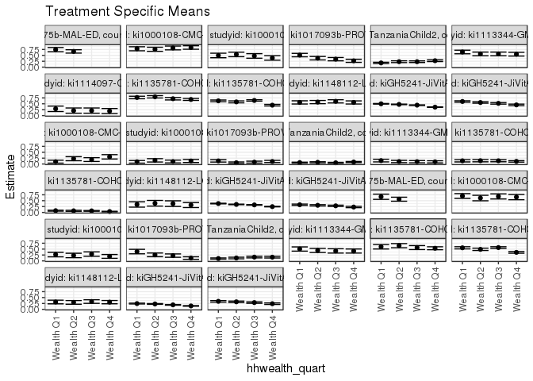

[figure not shown]

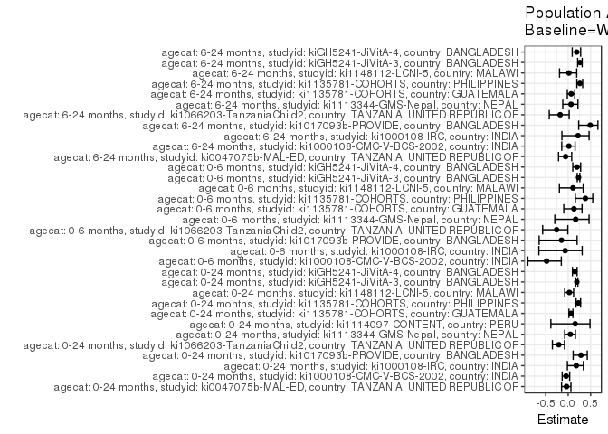

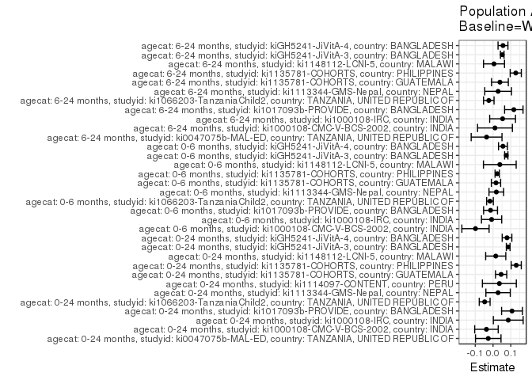

## Results Table

### Parameter: TSM

| agecat | studyid | country | intervention_level | baseline_level | estimate | ci_lower | ci_upper |
| --- | --- | --- | --- | --- | --- | --- | --- |
| 0-24 months | ki0047075b-MAL-ED | TANZANIA, UNITED REPUBLIC OF | Wealth Q1 | NA | 0.7435897 | 0.6537614 | 0.8334180 |
| 0-24 months | ki0047075b-MAL-ED | TANZANIA, UNITED REPUBLIC OF | Wealth Q2 | NA | 0.6666667 | 0.5955044 | 0.7378289 |
| 0-24 months | ki1000108-CMC-V-BCS-2002 | INDIA | Wealth Q4 | NA | 0.8333333 | 0.7586834 | 0.9079832 |
| 0-24 months | ki1000108-CMC-V-BCS-2002 | INDIA | Wealth Q1 | NA | 0.7802198 | 0.6950250 | 0.8654146 |
| 0-24 months | ki1000108-CMC-V-BCS-2002 | INDIA | Wealth Q2 | NA | 0.7578947 | 0.6716414 | 0.8441481 |
| 0-24 months | ki1000108-CMC-V-BCS-2002 | INDIA | Wealth Q3 | NA | 0.8131868 | 0.7329988 | 0.8933748 |
| 0-24 months | ki1000108-IRC | INDIA | Wealth Q4 | NA | 0.3900000 | 0.2942860 | 0.4857140 |
| 0-24 months | ki1000108-IRC | INDIA | Wealth Q1 | NA | 0.4952381 | 0.3994891 | 0.5909870 |
| 0-24 months | ki1000108-IRC | INDIA | Wealth Q2 | NA | 0.5392157 | 0.4423637 | 0.6360676 |
| 0-24 months | ki1000108-IRC | INDIA | Wealth Q3 | NA | 0.4757282 | 0.3791637 | 0.5722926 |
| 0-24 months | ki1017093b-PROVIDE | BANGLADESH | Wealth Q4 | NA | 0.2685714 | 0.2028577 | 0.3342852 |
| 0-24 months | ki1017093b-PROVIDE | BANGLADESH | Wealth Q1 | NA | 0.5111111 | 0.4380332 | 0.5841890 |
| 0-24 months | ki1017093b-PROVIDE | BANGLADESH | Wealth Q2 | NA | 0.3786982 | 0.3055146 | 0.4518819 |
| 0-24 months | ki1017093b-PROVIDE | BANGLADESH | Wealth Q3 | NA | 0.3390805 | 0.2686905 | 0.4094704 |
| 0-24 months | ki1066203-TanzaniaChild2 | TANZANIA, UNITED REPUBLIC OF | Wealth Q4 | NA | 0.2731872 | 0.2373154 | 0.3090590 |
| 0-24 months | ki1066203-TanzaniaChild2 | TANZANIA, UNITED REPUBLIC OF | Wealth Q1 | NA | 0.1794159 | 0.1513637 | 0.2074680 |
| 0-24 months | ki1066203-TanzaniaChild2 | TANZANIA, UNITED REPUBLIC OF | Wealth Q2 | NA | 0.2318841 | 0.1942384 | 0.2695297 |
| 0-24 months | ki1066203-TanzaniaChild2 | TANZANIA, UNITED REPUBLIC OF | Wealth Q3 | NA | 0.2308998 | 0.1968602 | 0.2649395 |
| 0-24 months | ki1113344-GMS-Nepal | NEPAL | Wealth Q4 | NA | 0.5496689 | 0.4702475 | 0.6290902 |
| 0-24 months | ki1113344-GMS-Nepal | NEPAL | Wealth Q1 | NA | 0.6423841 | 0.5658727 | 0.7188956 |
| 0-24 months | ki1113344-GMS-Nepal | NEPAL | Wealth Q2 | NA | 0.5600000 | 0.4804969 | 0.6395031 |
| 0-24 months | ki1113344-GMS-Nepal | NEPAL | Wealth Q3 | NA | 0.5600000 | 0.4804969 | 0.6395031 |
| 0-24 months | ki1114097-CONTENT | PERU | Wealth Q4 | NA | 0.1923077 | 0.0849384 | 0.2996770 |
| 0-24 months | ki1114097-CONTENT | PERU | Wealth Q1 | NA | 0.2881356 | 0.1723028 | 0.4039684 |
| 0-24 months | ki1114097-CONTENT | PERU | Wealth Q2 | NA | 0.2115385 | 0.1002773 | 0.3227996 |
| 0-24 months | ki1114097-CONTENT | PERU | Wealth Q3 | NA | 0.2115385 | 0.1002773 | 0.3227996 |
| 0-24 months | ki1135781-COHORTS | GUATEMALA | Wealth Q4 | NA | 0.6845361 | 0.6431628 | 0.7259094 |
| 0-24 months | ki1135781-COHORTS | GUATEMALA | Wealth Q1 | NA | 0.7673469 | 0.7144190 | 0.8202749 |
| 0-24 months | ki1135781-COHORTS | GUATEMALA | Wealth Q2 | NA | 0.7961538 | 0.7471668 | 0.8451409 |
| 0-24 months | ki1135781-COHORTS | GUATEMALA | Wealth Q3 | NA | 0.7152778 | 0.6631379 | 0.7674176 |

[output cut: 98 more lines]

### Parameter: E(Y)

| agecat | studyid | country | intervention_level | baseline_level | estimate | ci_lower | ci_upper |
| --- | --- | --- | --- | --- | --- | --- | --- |
| 0-24 months | ki0047075b-MAL-ED | TANZANIA, UNITED REPUBLIC OF | NA | NA | 0.7166667 | 0.6016848 | 0.8316486 |
| 0-24 months | ki1000108-CMC-V-BCS-2002 | INDIA | NA | NA | 0.7962466 | 0.7553156 | 0.8371777 |
| 0-24 months | ki1000108-IRC | INDIA | NA | NA | 0.4756098 | 0.4272105 | 0.5240091 |
| 0-24 months | ki1017093b-PROVIDE | BANGLADESH | NA | NA | 0.3753582 | 0.3394105 | 0.4113058 |
| 0-24 months | ki1066203-TanzaniaChild2 | TANZANIA, UNITED REPUBLIC OF | NA | NA | 0.2260906 | 0.2092959 | 0.2428853 |
| 0-24 months | ki1113344-GMS-Nepal | NEPAL | NA | NA | 0.5780731 | 0.5385891 | 0.6175571 |
| 0-24 months | ki1114097-CONTENT | PERU | NA | NA | 0.2279070 | 0.1717046 | 0.2841094 |
| 0-24 months | ki1135781-COHORTS | GUATEMALA | NA | NA | 0.7300469 | 0.7056985 | 0.7543954 |
| 0-24 months | ki1135781-COHORTS | PHILIPPINES | NA | NA | 0.5718024 | 0.5542589 | 0.5893459 |
| 0-24 months | ki1148112-LCNI-5 | MALAWI | NA | NA | 0.5728274 | 0.5388870 | 0.6067678 |
| 0-24 months | kiGH5241-JiVitA-3 | BANGLADESH | NA | NA | 0.4438483 | 0.4363245 | 0.4513721 |
| 0-24 months | kiGH5241-JiVitA-4 | BANGLADESH | NA | NA | 0.5322521 | 0.5160648 | 0.5484394 |
| 0-6 months | ki1000108-CMC-V-BCS-2002 | INDIA | NA | NA | 0.2065217 | 0.1651060 | 0.2479375 |
| 0-6 months | ki1000108-IRC | INDIA | NA | NA | 0.1219512 | 0.0902381 | 0.1536643 |
| 0-6 months | ki1017093b-PROVIDE | BANGLADESH | NA | NA | 0.0945559 | 0.0728335 | 0.1162782 |
| 0-6 months | ki1066203-TanzaniaChild2 | TANZANIA, UNITED REPUBLIC OF | NA | NA | 0.0671141 | 0.0570678 | 0.0771604 |
| 0-6 months | ki1113344-GMS-Nepal | NEPAL | NA | NA | 0.1112957 | 0.0861520 | 0.1364394 |
| 0-6 months | ki1135781-COHORTS | GUATEMALA | NA | NA | 0.1292189 | 0.1087928 | 0.1496450 |
| 0-6 months | ki1135781-COHORTS | PHILIPPINES | NA | NA | 0.0614982 | 0.0529805 | 0.0700159 |
| 0-6 months | ki1148112-LCNI-5 | MALAWI | NA | NA | 0.3531599 | 0.2959376 | 0.4103821 |
| 0-6 months | kiGH5241-JiVitA-3 | BANGLADESH | NA | NA | 0.3219627 | 0.3152023 | 0.3287231 |
| 0-6 months | kiGH5241-JiVitA-4 | BANGLADESH | NA | NA | 0.2864960 | 0.2726657 | 0.3003263 |
| 6-24 months | ki0047075b-MAL-ED | TANZANIA, UNITED REPUBLIC OF | NA | NA | 0.6304348 | 0.4894061 | 0.7714635 |
| 6-24 months | ki1000108-CMC-V-BCS-2002 | INDIA | NA | NA | 0.6631944 | 0.6085159 | 0.7178730 |
| 6-24 months | ki1000108-IRC | INDIA | NA | NA | 0.2448378 | 0.1989973 | 0.2906782 |
| 6-24 months | ki1017093b-PROVIDE | BANGLADESH | NA | NA | 0.2383838 | 0.2008095 | 0.2759582 |
| 6-24 months | ki1066203-TanzaniaChild2 | TANZANIA, UNITED REPUBLIC OF | NA | NA | 0.1342391 | 0.1186581 | 0.1498201 |
| 6-24 months | ki1113344-GMS-Nepal | NEPAL | NA | NA | 0.4479167 | 0.4033837 | 0.4924496 |
| 6-24 months | ki1135781-COHORTS | GUATEMALA | NA | NA | 0.5750000 | 0.5354120 | 0.6145880 |
| 6-24 months | ki1135781-COHORTS | PHILIPPINES | NA | NA | 0.4901079 | 0.4693271 | 0.5108888 |
| 6-24 months | ki1148112-LCNI-5 | MALAWI | NA | NA | 0.3108808 | 0.2731472 | 0.3486144 |
| 6-24 months | kiGH5241-JiVitA-3 | BANGLADESH | NA | NA | 0.1970221 | 0.1889626 | 0.2050817 |
| 6-24 months | kiGH5241-JiVitA-4 | BANGLADESH | NA | NA | 0.2954018 | 0.2790421 | 0.3117615 |

### Parameter: RR

| agecat | studyid | country | intervention_level | baseline_level | estimate | ci_lower | ci_upper |
| --- | --- | --- | --- | --- | --- | --- | --- |
| 0-24 months | ki0047075b-MAL-ED | TANZANIA, UNITED REPUBLIC OF | Wealth Q1 | Wealth Q1 | 1.0000000 | 1.0000000 | 1.0000000 |
| 0-24 months | ki0047075b-MAL-ED | TANZANIA, UNITED REPUBLIC OF | Wealth Q2 | Wealth Q1 | 0.8965517 | 0.7630695 | 1.0533837 |
| 0-24 months | ki1000108-CMC-V-BCS-2002 | INDIA | Wealth Q4 | Wealth Q4 | 1.0000000 | 1.0000000 | 1.0000000 |
| 0-24 months | ki1000108-CMC-V-BCS-2002 | INDIA | Wealth Q1 | Wealth Q4 | 0.9362637 | 0.8129428 | 1.0782921 |
| 0-24 months | ki1000108-CMC-V-BCS-2002 | INDIA | Wealth Q2 | Wealth Q4 | 0.9094737 | 0.7868468 | 1.0512115 |
| 0-24 months | ki1000108-CMC-V-BCS-2002 | INDIA | Wealth Q3 | Wealth Q4 | 0.9758242 | 0.8541094 | 1.1148839 |
| 0-24 months | ki1000108-IRC | INDIA | Wealth Q4 | Wealth Q4 | 1.0000000 | 1.0000000 | 1.0000000 |
| 0-24 months | ki1000108-IRC | INDIA | Wealth Q1 | Wealth Q4 | 1.2698413 | 0.9291025 | 1.7355424 |
| 0-24 months | ki1000108-IRC | INDIA | Wealth Q2 | Wealth Q4 | 1.3826043 | 1.0200400 | 1.8740390 |
| 0-24 months | ki1000108-IRC | INDIA | Wealth Q3 | Wealth Q4 | 1.2198158 | 0.8871104 | 1.6773004 |
| 0-24 months | ki1017093b-PROVIDE | BANGLADESH | Wealth Q4 | Wealth Q4 | 1.0000000 | 1.0000000 | 1.0000000 |
| 0-24 months | ki1017093b-PROVIDE | BANGLADESH | Wealth Q1 | Wealth Q4 | 1.9030733 | 1.4334425 | 2.5265666 |
| 0-24 months | ki1017093b-PROVIDE | BANGLADESH | Wealth Q2 | Wealth Q4 | 1.4100466 | 1.0323440 | 1.9259388 |
| 0-24 months | ki1017093b-PROVIDE | BANGLADESH | Wealth Q3 | Wealth Q4 | 1.2625336 | 0.9159845 | 1.7401944 |
| 0-24 months | ki1066203-TanzaniaChild2 | TANZANIA, UNITED REPUBLIC OF | Wealth Q4 | Wealth Q4 | 1.0000000 | 1.0000000 | 1.0000000 |
| 0-24 months | ki1066203-TanzaniaChild2 | TANZANIA, UNITED REPUBLIC OF | Wealth Q1 | Wealth Q4 | 0.6567506 | 0.5354608 | 0.8055145 |
| 0-24 months | ki1066203-TanzaniaChild2 | TANZANIA, UNITED REPUBLIC OF | Wealth Q2 | Wealth Q4 | 0.8488102 | 0.6888567 | 1.0459050 |
| 0-24 months | ki1066203-TanzaniaChild2 | TANZANIA, UNITED REPUBLIC OF | Wealth Q3 | Wealth Q4 | 0.8452074 | 0.6937842 | 1.0296797 |
| 0-24 months | ki1113344-GMS-Nepal | NEPAL | Wealth Q4 | Wealth Q4 | 1.0000000 | 1.0000000 | 1.0000000 |
| 0-24 months | ki1113344-GMS-Nepal | NEPAL | Wealth Q1 | Wealth Q4 | 1.1686747 | 0.9691057 | 1.4093412 |
| 0-24 months | ki1113344-GMS-Nepal | NEPAL | Wealth Q2 | Wealth Q4 | 1.0187952 | 0.8319821 | 1.2475552 |
| 0-24 months | ki1113344-GMS-Nepal | NEPAL | Wealth Q3 | Wealth Q4 | 1.0187952 | 0.8319821 | 1.2475552 |
| 0-24 months | ki1114097-CONTENT | PERU | Wealth Q4 | Wealth Q4 | 1.0000000 | 1.0000000 | 1.0000000 |
| 0-24 months | ki1114097-CONTENT | PERU | Wealth Q1 | Wealth Q4 | 1.4983051 | 0.7530251 | 2.9811995 |
| 0-24 months | ki1114097-CONTENT | PERU | Wealth Q2 | Wealth Q4 | 1.1000000 | 0.5108218 | 2.3687322 |
| 0-24 months | ki1114097-CONTENT | PERU | Wealth Q3 | Wealth Q4 | 1.1000000 | 0.5108218 | 2.3687322 |
| 0-24 months | ki1135781-COHORTS | GUATEMALA | Wealth Q4 | Wealth Q4 | 1.0000000 | 1.0000000 | 1.0000000 |
| 0-24 months | ki1135781-COHORTS | GUATEMALA | Wealth Q1 | Wealth Q4 | 1.1209737 | 1.0227433 | 1.2286388 |
| 0-24 months | ki1135781-COHORTS | GUATEMALA | Wealth Q2 | Wealth Q4 | 1.1630561 | 1.0669479 | 1.2678214 |
| 0-24 months | ki1135781-COHORTS | GUATEMALA | Wealth Q3 | Wealth Q4 | 1.0449088 | 0.9505044 | 1.1486895 |

[output cut: 98 more lines]

### Parameter: PAR

| agecat | studyid | country | intervention_level | baseline_level | estimate | ci_lower | ci_upper |
| --- | --- | --- | --- | --- | --- | --- | --- |
| 0-24 months | ki0047075b-MAL-ED | TANZANIA, UNITED REPUBLIC OF | Wealth Q1 | NA | -0.0269231 | -0.0986985 | 0.0448524 |
| 0-24 months | ki1000108-CMC-V-BCS-2002 | INDIA | Wealth Q4 | NA | -0.0370867 | -0.1032644 | 0.0290910 |
| 0-24 months | ki1000108-IRC | INDIA | Wealth Q4 | NA | 0.0856098 | 0.0017360 | 0.1694835 |
| 0-24 months | ki1017093b-PROVIDE | BANGLADESH | Wealth Q4 | NA | 0.1067867 | 0.0480910 | 0.1654825 |
| 0-24 months | ki1066203-TanzaniaChild2 | TANZANIA, UNITED REPUBLIC OF | Wealth Q4 | NA | -0.0470966 | -0.0775711 | -0.0166221 |
| 0-24 months | ki1113344-GMS-Nepal | NEPAL | Wealth Q4 | NA | 0.0284042 | -0.0401697 | 0.0969781 |
| 0-24 months | ki1114097-CONTENT | PERU | Wealth Q4 | NA | 0.0355993 | -0.0598494 | 0.1310480 |
| 0-24 months | ki1135781-COHORTS | GUATEMALA | Wealth Q4 | NA | 0.0455109 | 0.0138031 | 0.0772187 |
| 0-24 months | ki1135781-COHORTS | PHILIPPINES | Wealth Q4 | NA | 0.1305213 | 0.1020290 | 0.1590136 |
| 0-24 months | ki1148112-LCNI-5 | MALAWI | Wealth Q4 | NA | 0.0152237 | -0.0413590 | 0.0718065 |
| 0-24 months | kiGH5241-JiVitA-3 | BANGLADESH | Wealth Q4 | NA | 0.0851861 | 0.0748398 | 0.0955325 |
| 0-24 months | kiGH5241-JiVitA-4 | BANGLADESH | Wealth Q4 | NA | 0.0787002 | 0.0515028 | 0.1058976 |
| 0-6 months | ki1000108-CMC-V-BCS-2002 | INDIA | Wealth Q4 | NA | -0.0987414 | -0.1753872 | -0.0220957 |
| 0-6 months | ki1000108-IRC | INDIA | Wealth Q4 | NA | -0.0080488 | -0.0649389 | 0.0488414 |
| 0-6 months | ki1017093b-PROVIDE | BANGLADESH | Wealth Q4 | NA | -0.0140156 | -0.0531639 | 0.0251328 |
| 0-6 months | ki1066203-TanzaniaChild2 | TANZANIA, UNITED REPUBLIC OF | Wealth Q4 | NA | -0.0172029 | -0.0359744 | 0.0015686 |
| 0-6 months | ki1113344-GMS-Nepal | NEPAL | Wealth Q4 | NA | 0.0185804 | -0.0226558 | 0.0598166 |
| 0-6 months | ki1135781-COHORTS | GUATEMALA | Wealth Q4 | NA | 0.0166535 | -0.0094605 | 0.0427674 |
| 0-6 months | ki1135781-COHORTS | PHILIPPINES | Wealth Q4 | NA | 0.0235385 | 0.0114056 | 0.0356714 |
| 0-6 months | ki1148112-LCNI-5 | MALAWI | Wealth Q4 | NA | 0.0380914 | -0.0540297 | 0.1302124 |
| 0-6 months | kiGH5241-JiVitA-3 | BANGLADESH | Wealth Q4 | NA | 0.0745021 | 0.0651967 | 0.0838075 |
| 0-6 months | kiGH5241-JiVitA-4 | BANGLADESH | Wealth Q4 | NA | 0.0558549 | 0.0307872 | 0.0809225 |
| 6-24 months | ki0047075b-MAL-ED | TANZANIA, UNITED REPUBLIC OF | Wealth Q1 | NA | -0.0362319 | -0.1229339 | 0.0504701 |
| 6-24 months | ki1000108-CMC-V-BCS-2002 | INDIA | Wealth Q4 | NA | 0.0110205 | -0.0869097 | 0.1089507 |
| 6-24 months | ki1000108-IRC | INDIA | Wealth Q4 | NA | 0.0538265 | -0.0188257 | 0.1264787 |
| 6-24 months | ki1017093b-PROVIDE | BANGLADESH | Wealth Q4 | NA | 0.1169553 | 0.0651300 | 0.1687805 |
| 6-24 months | ki1066203-TanzaniaChild2 | TANZANIA, UNITED REPUBLIC OF | Wealth Q4 | NA | -0.0239004 | -0.0535073 | 0.0057065 |
| 6-24 months | ki1113344-GMS-Nepal | NEPAL | Wealth Q4 | NA | 0.0285618 | -0.0465166 | 0.1036402 |
| 6-24 months | ki1135781-COHORTS | GUATEMALA | Wealth Q4 | NA | 0.0387097 | -0.0085768 | 0.0859961 |
| 6-24 months | ki1135781-COHORTS | PHILIPPINES | Wealth Q4 | NA | 0.1278553 | 0.0964737 | 0.1592368 |
| 6-24 months | ki1148112-LCNI-5 | MALAWI | Wealth Q4 | NA | 0.0054916 | -0.0536026 | 0.0645858 |
| 6-24 months | kiGH5241-JiVitA-3 | BANGLADESH | Wealth Q4 | NA | 0.0517817 | 0.0417000 | 0.0618634 |
| 6-24 months | kiGH5241-JiVitA-4 | BANGLADESH | Wealth Q4 | NA | 0.0560302 | 0.0282171 | 0.0838434 |

### Parameter: PAF

| agecat | studyid | country | intervention_level | baseline_level | estimate | ci_lower | ci_upper |
| --- | --- | --- | --- | --- | --- | --- | --- |
| 0-24 months | ki0047075b-MAL-ED | TANZANIA, UNITED REPUBLIC OF | Wealth Q1 | NA | -0.0375671 | -0.1469809 | 0.0614095 |
| 0-24 months | ki1000108-CMC-V-BCS-2002 | INDIA | Wealth Q4 | NA | -0.0465769 | -0.1333458 | 0.0335490 |
| 0-24 months | ki1000108-IRC | INDIA | Wealth Q4 | NA | 0.1800000 | -0.0173230 | 0.3390496 |
| 0-24 months | ki1017093b-PROVIDE | BANGLADESH | Wealth Q4 | NA | 0.2844929 | 0.1101309 | 0.4246902 |
| 0-24 months | ki1066203-TanzaniaChild2 | TANZANIA, UNITED REPUBLIC OF | Wealth Q4 | NA | -0.2083084 | -0.3506105 | -0.0809995 |
| 0-24 months | ki1113344-GMS-Nepal | NEPAL | Wealth Q4 | NA | 0.0491360 | -0.0772923 | 0.1607271 |
| 0-24 months | ki1114097-CONTENT | PERU | Wealth Q4 | NA | 0.1562009 | -0.3846367 | 0.4857880 |
| 0-24 months | ki1135781-COHORTS | GUATEMALA | Wealth Q4 | NA | 0.0623396 | 0.0176737 | 0.1049746 |
| 0-24 months | ki1135781-COHORTS | PHILIPPINES | Wealth Q4 | NA | 0.2282629 | 0.1762358 | 0.2770041 |
| 0-24 months | ki1148112-LCNI-5 | MALAWI | Wealth Q4 | NA | 0.0265765 | -0.0774096 | 0.1205263 |
| 0-24 months | kiGH5241-JiVitA-3 | BANGLADESH | Wealth Q4 | NA | 0.1919262 | 0.1680957 | 0.2150741 |
| 0-24 months | kiGH5241-JiVitA-4 | BANGLADESH | Wealth Q4 | NA | 0.1478626 | 0.0947840 | 0.1978290 |
| 0-6 months | ki1000108-CMC-V-BCS-2002 | INDIA | Wealth Q4 | NA | -0.4781163 | -0.8963102 | -0.1521469 |
| 0-6 months | ki1000108-IRC | INDIA | Wealth Q4 | NA | -0.0660000 | -0.6509014 | 0.3116755 |
| 0-6 months | ki1017093b-PROVIDE | BANGLADESH | Wealth Q4 | NA | -0.1482251 | -0.6452070 | 0.1986292 |
| 0-6 months | ki1066203-TanzaniaChild2 | TANZANIA, UNITED REPUBLIC OF | Wealth Q4 | NA | -0.2563238 | -0.5668964 | -0.0073094 |
| 0-6 months | ki1113344-GMS-Nepal | NEPAL | Wealth Q4 | NA | 0.1669467 | -0.2972892 | 0.4650554 |
| 0-6 months | ki1135781-COHORTS | GUATEMALA | Wealth Q4 | NA | 0.1288779 | -0.0976161 | 0.3086346 |
| 0-6 months | ki1135781-COHORTS | PHILIPPINES | Wealth Q4 | NA | 0.3827516 | 0.1594048 | 0.5467549 |
| 0-6 months | ki1148112-LCNI-5 | MALAWI | Wealth Q4 | NA | 0.1078587 | -0.1951078 | 0.3340215 |
| 0-6 months | kiGH5241-JiVitA-3 | BANGLADESH | Wealth Q4 | NA | 0.2313998 | 0.2019366 | 0.2597752 |
| 0-6 months | kiGH5241-JiVitA-4 | BANGLADESH | Wealth Q4 | NA | 0.1949586 | 0.1024981 | 0.2778938 |
| 6-24 months | ki0047075b-MAL-ED | TANZANIA, UNITED REPUBLIC OF | Wealth Q1 | NA | -0.0574713 | -0.2137827 | 0.0787103 |
| 6-24 months | ki1000108-CMC-V-BCS-2002 | INDIA | Wealth Q4 | NA | 0.0166173 | -0.1427313 | 0.1537455 |
| 6-24 months | ki1000108-IRC | INDIA | Wealth Q4 | NA | 0.2198457 | -0.1391471 | 0.4657048 |
| 6-24 months | ki1017093b-PROVIDE | BANGLADESH | Wealth Q4 | NA | 0.4906174 | 0.2339940 | 0.6612682 |
| 6-24 months | ki1066203-TanzaniaChild2 | TANZANIA, UNITED REPUBLIC OF | Wealth Q4 | NA | -0.1780435 | -0.4198522 | 0.0225839 |
| 6-24 months | ki1113344-GMS-Nepal | NEPAL | Wealth Q4 | NA | 0.0637659 | -0.1198669 | 0.2172872 |
| 6-24 months | ki1135781-COHORTS | GUATEMALA | Wealth Q4 | NA | 0.0673212 | -0.0188678 | 0.1462191 |
| 6-24 months | ki1135781-COHORTS | PHILIPPINES | Wealth Q4 | NA | 0.2608716 | 0.1935492 | 0.3225740 |
| 6-24 months | ki1148112-LCNI-5 | MALAWI | Wealth Q4 | NA | 0.0176647 | -0.1920572 | 0.1904896 |
| 6-24 months | kiGH5241-JiVitA-3 | BANGLADESH | Wealth Q4 | NA | 0.2628217 | 0.2109741 | 0.3112623 |
| 6-24 months | kiGH5241-JiVitA-4 | BANGLADESH | Wealth Q4 | NA | 0.1896747 | 0.0898333 | 0.2785639 |